# HW4-Predictive regression modeling with R

misken

February 9, 2018

## Step 1 - Familiarize yourself with the data and the assignment

In this assignment you’ll build some predictive regression models with R on a dataset containing inpatient discharges from hospitals in New York.

The version of this data that we’ll be using is from a Kaggle dataset. See https://www.kaggle.com/jonasalmeida/2015-deidentified-ny-inpatient-discharge-sparcs. Unfortunately, the column metadata wasn’t posted. However, since this is a publicly available dataset, we can visit the source at https://health.data.ny.gov/Health/Hospital-Inpatient-Discharges-SPARCS-De-Identified/82xm-y6g8.

If you scroll down on that page you’ll find descriptions of the columns (click the little Show All link to display the entire list).

Most of the fields are self-explanatory. You’ll notice that there are several sets of diagnosis and procedure codes. A few definitions are helpful.

### DRG - Diagnosis Related Groups

DRGs are a coding system developed in the 1980s that form the basis of how hospitals are reimbursed from Medicare (US Govt) or private insurers. After a patient is discharged from the hospital, a program known as a *DRG grouper* uses information such as diagnosis and procedure codes (ICD-9-CM) to assign a DRG to the patient. A full list of the over 900 DRGs can be found at:

https://www.cms.gov/Research-Statistics-Data-and-Systems/Statistics-Trends-and-Reports/MedicareFeeforSvcPartsAB/downloads/DRGdesc08.pdf

In that list you’ll see that MDC (Medical Diagnostic Category) is simply a grouping of DRGs.

### CCS - Clinical Classification System

The [CCS](https://www.hcup-us.ahrq.gov/toolssoftware/ccs/ccs.jsp) system was developed by the [Agency for Healthcare Research and Quality (AHRQ)](https://www.ahrq.gov/) to provide a classification system better suited to healthcare research. There are CCS diagnosis codes and CCS procedure codes. From their website:

> The Clinical Classifications Software (CCS) for ICD-9-CM is a diagnosis and procedure categorization scheme that can be employed in many types of projects analyzing data on diagnoses and procedures. CCS is based on the International Classification of Diseases, 9th Revision, Clinical Modification (ICD-9-CM), a uniform and standardized coding system. The ICD-9-CM’s multitude of codes - over 14,000 diagnosis codes and 3,900 procedure codes - are collapsed into a smaller number of clinically meaningful categories that are sometimes more useful for presenting descriptive statistics than are individual ICD-9-CM codes.

As we did in class, you’ll be creating an R Markdown document to do the analysis as well as to document the steps you did (and answer some questions I’ll throw at you).

You’ll notice a few “Hacker Extra” tasks thrown in. These are for those of you who want to go a little above and beyond and attempt some more challenging tasks.

## Step 2 - Create a new R Markdown document

Save this file as a new R Markdown document and name it something that includes your last name in the filename. Save it into the same folder as this file.

## Step 3 - Create project and load data

Create an R Studio project in the current folder (the one containing this file). You’ll notice that there is a folder named **data**. Inside of it you’ll find the data file for this assignment:

- **ipd_resp.RData**

The full dataset contains over two million records and is available as a CSV file from Kaggle. I did a little data filtering and cleaning to create a subset to use for this regression assignment. Specifically, I did the following:

- used dplyr to filter records so that we were just working with `APR MDC Code` == 4. These are patients having respiratory related diagnoses.
- a bunch of fields were read in as `chr` and I changed them to factors using `as.factor`.
- There were some fields we don’t need and they were dropped.
- Just as in HW1, I cleaned up the charges and costs fields that got interpreted as `chr` because of the leading dollar sign. Now they are numeric.
- Modified some field names to make them easier to work with.

See the data prep script for all the details. You do **NOT** need to run the data prep script. I’m just including it so you can see a typical data prep script.

### Load the data

```r
load("./data/ipd_resp.RData")
#str(ipd_resp)
```

## Step 4 - Partition into training and test sets

Just run this chunk to create training and test datasets. This way we’ll all be working with the same datasets. Notice that the test set is 30% of the full dataset.

```r
set.seed(1828)
sample_size <- ceiling(0.30 * nrow(ipd_resp))
testrecs <- sample(nrow(ipd_resp),sample_size)
ipd_test <- ipd_resp[testrecs,]
ipd_train <- ipd_resp[-testrecs,]  # Negative in front of vector means "not in"
rm(ipd_resp) # No sense keeping a copy of the entire dataset around
```

## Step 5 - EDA on training data

Now start with some EDA on the training dataset`ipd_train`. The test data will only get used after building models and want to compare their predictive abilities.

As mentioned above, the dependent variable that we are trying to predict is `Total_Charges` - this is the amount that the hospital submits to whomever is paying the bill for the hospital stay. This is usually an insurance company, the federal Medicare or Medicaid program, an employer who self-insurers or the patient. The `Payment_Typology_1` field contains the primary payer to whom the charges are submitted. If you look at the relationship between `Total_Costs` and `Total_Charges`, you’ll start to see why the economics of the US healthcare system is hard to understand.

You’ll notice that `ipd_train` contains a few numeric fields and many factors (categorical data). You are free to use any of these fields in your regression models to predict `Total_Charges`.

Start by using things like ggplot2 and dplyr to explore the training dataset. You can use other packages as well. Your goal is to gain a general understanding of the variables and perhaps uncover some useful relationships that you can use in your regression models.

**NOTE: In the data prep phase I made sure there were no NA values in the data frames that we are using for this assignment. So, no need to worry about that.**

```r
library(dplyr)
```

```r
library(ggplot2)
```

```r
summary(ipd_train)
```

```
##      Health_Service_Area  Hospital_County   Facility_Id
##  New York City :59355    Manhattan:17112   1169   :  3769
##  Long Island   :18906    Kings    :14286   1464   :  2655
##  Hudson Valley :14989    Bronx    :13883   1172   :  2517
##  Capital/Adiron:11629    Queens   :10931   1178   :  2341
##  Central NY    :10770    Suffolk  : 9603   1458   :  2091
##  Western NY    :10456    Nassau   : 9303   413    :  2013
##  (Other)       :11215    (Other)  :62202   (Other):121934
##                                                         Facility_Name
##  Montefiore Medical Center - Henry & Lucy Moses Div            :  3769
##  New York Presbyterian Hospital - Columbia Presbyterian Center :  2655
##  Lincoln Medical & Mental Health Center                        :  2517
##  Bronx-Lebanon Hospital Center - Concourse Division            :  2341
##  New York Presbyterian Hospital - New York Weill Cornell Center:  2091
##  Good Samaritan Hospital Medical Center                        :  2013
##  (Other)                                                       :121934
##        Age_Group        ZipCode      Gender
##  0 to 17    :18955   112    :16184   F:72465
##  18 to 29   : 4410   104    :15118   M:64855
##  30 to 49   :13174   117    :10422   U:    0
##  50 to 69   :44726   100    : 8879
##  70 or Older:56055   113    : 6190
##                      115    : 4771
##                      (Other):75756
##                      Race                   Ethnicity
##  Black/African American:26759   Multi-ethnic     :   533
##  Multi-racial          : 1248   Not Span/Hispanic:114997
##  Other Race            :28283   Spanish/Hispanic : 16107
##  White                 :81030   Unknown          :  5683
##
##
##
##  Length_of_Stay        Type_of_Admission
##  Min.   :  1.000   Elective     :  7833
##  1st Qu.:  2.000   Emergency    :123327
##  Median :  4.000   Newborn      :    15
##  Mean   :  5.591   Not Available:    56
##  3rd Qu.:  7.000   Trauma       :   391
##  Max.   :119.000   Urgent       :  5698
##
```

[output cut: 41 more lines]

```
##  Extreme :14310               Extreme : 9920
##  Major   :46752               Major   :36936
##  Minor   :23375               Minor   :50734
##  Moderate:52883               Moderate:39730
##  unknown :    0
##
##
##                  Payment_Typology_1 Total_Charges      Total_Costs
##  Medicare                 :72837    Min.   :      1   Min.   :     0.6
##  Medicaid                 :34848    1st Qu.:  13190   1st Qu.:  5283.6
##  Private Health Insurance :12315    Median :  24485   Median :  8998.8
##  Blue Cross/Blue Shield   :10478    Mean   :  41551   Mean   : 15527.7
##  Self-Pay                 : 3150    3rd Qu.:  46436   3rd Qu.: 16499.2
##  Managed Care, Unspecified: 1292    Max.   :2691248   Max.   :689872.8
##  (Other)                  : 2400
```

Now, it’s your turn …

### Feature engineering

```r
ipd_train$surgery <- ifelse(ipd_train$CCS_Proc_Code != 0, 1, 0)
ipd_test$surgery <- ifelse(ipd_test$CCS_Proc_Code != 0, 1, 0)
summary(ipd_train$surgery)
```

```
##    Min. 1st Qu.  Median    Mean 3rd Qu.    Max.
##  0.0000  0.0000  1.0000  0.5945  1.0000  1.0000
```

### Correlation matrix on the numeric variables

```r
cor(ipd_train[, c("Length_of_Stay", "Total_Charges", "Total_Costs")])
```

```
##                Length_of_Stay Total_Charges Total_Costs
## Length_of_Stay      1.0000000     0.7874142   0.7847404
## Total_Charges       0.7874142     1.0000000   0.8621902
## Total_Costs         0.7847404     0.8621902   1.0000000
```

### Histograms of costs and charges

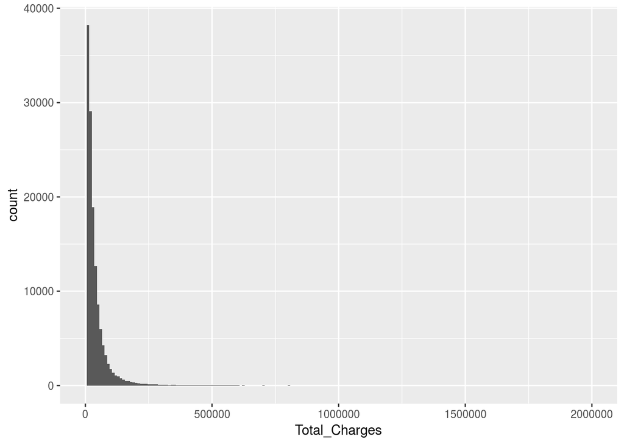

```r
ggplot(ipd_train) + geom_histogram(aes(x=Total_Charges), bins = 200) +
  xlim(0,2e+06)
```

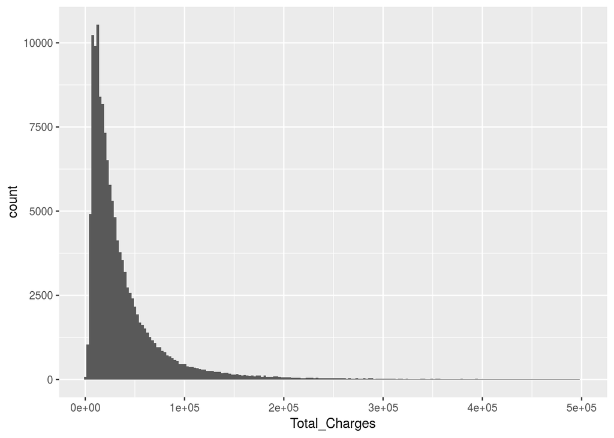

```r
ipd_train %>%
  filter(Total_Charges < 500000) %>%
  ggplot() + geom_histogram(aes(x=Total_Charges), bins = 200)
```

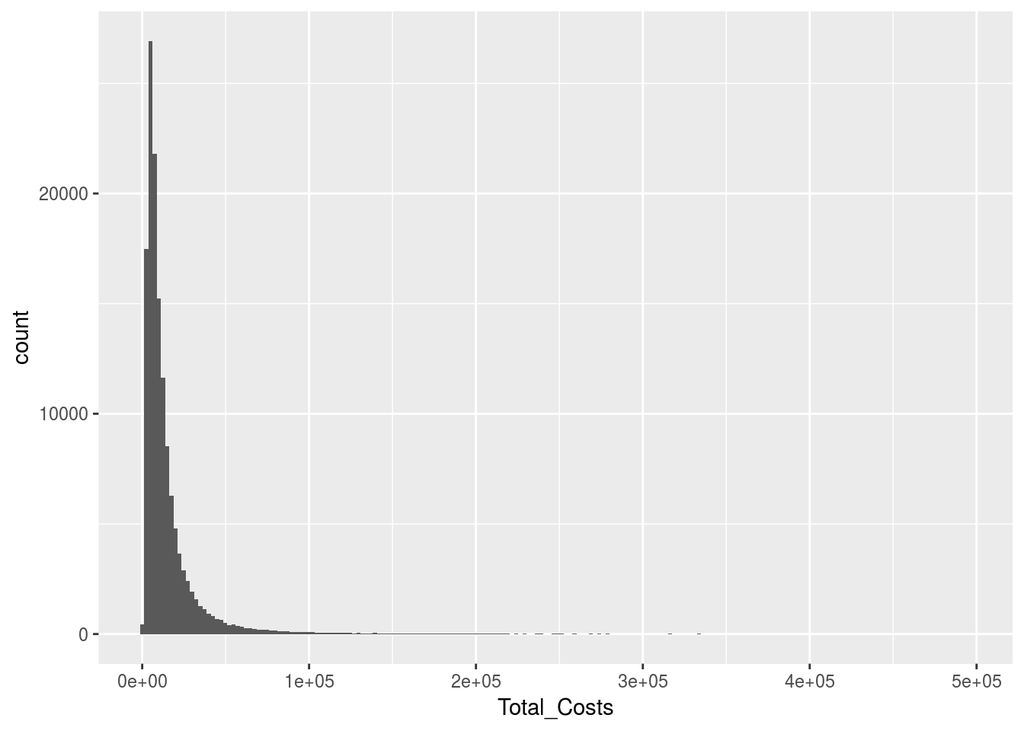

```r
ipd_train %>%
  filter(Total_Costs < 500000) %>%
  ggplot() + geom_histogram(aes(x=Total_Costs), bins = 200)
```

### Scatter LOS vs charges

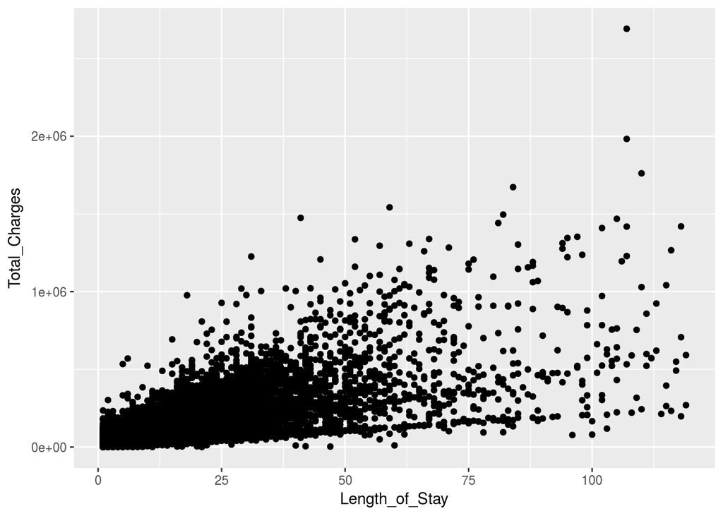

```r
ggplot(ipd_train) + geom_point(aes(x=Length_of_Stay, y=Total_Charges))
```

Faceted by Health Service Area

```r
ipd_train %>%
  group_by(Health_Service_Area) %>%
  summarize(mean_costs=mean(Total_Costs),
            mean_charges=mean(Total_Charges),
            numpats=n())
```

```
## # A tibble: 8 x 4
##   Health_Service_Area mean_costs mean_charges numpats
##                <fctr>      <dbl>        <dbl>   <int>
## 1      Capital/Adiron  11390.015     31585.75   11629
## 2          Central NY  11462.565     24651.72   10770
## 3        Finger Lakes  10288.634     20924.51    9226
## 4       Hudson Valley  14286.343     47505.61   14989
## 5         Long Island  13976.165     56079.55   18906
## 6       New York City  19695.040     47432.00   59355
## 7       Southern Tier   8354.151     21098.15    1989
## 8          Western NY  11232.183     23945.46   10456
```

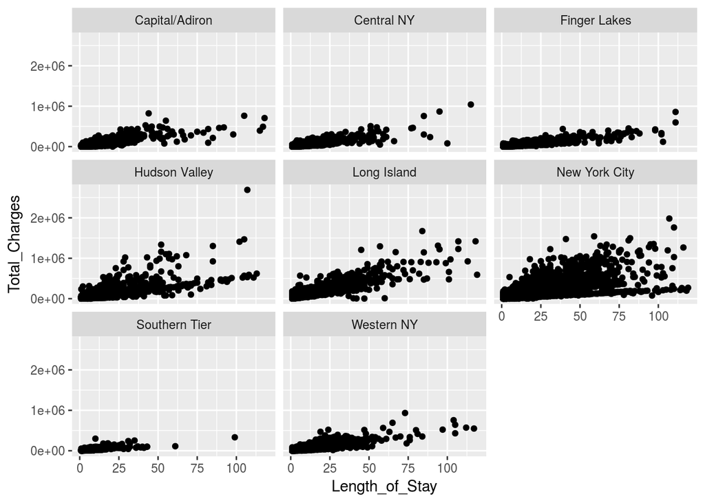

```r
ggplot(ipd_train) + geom_point(aes(x=Length_of_Stay, y=Total_Charges)) +
  facet_wrap(~Health_Service_Area)
```

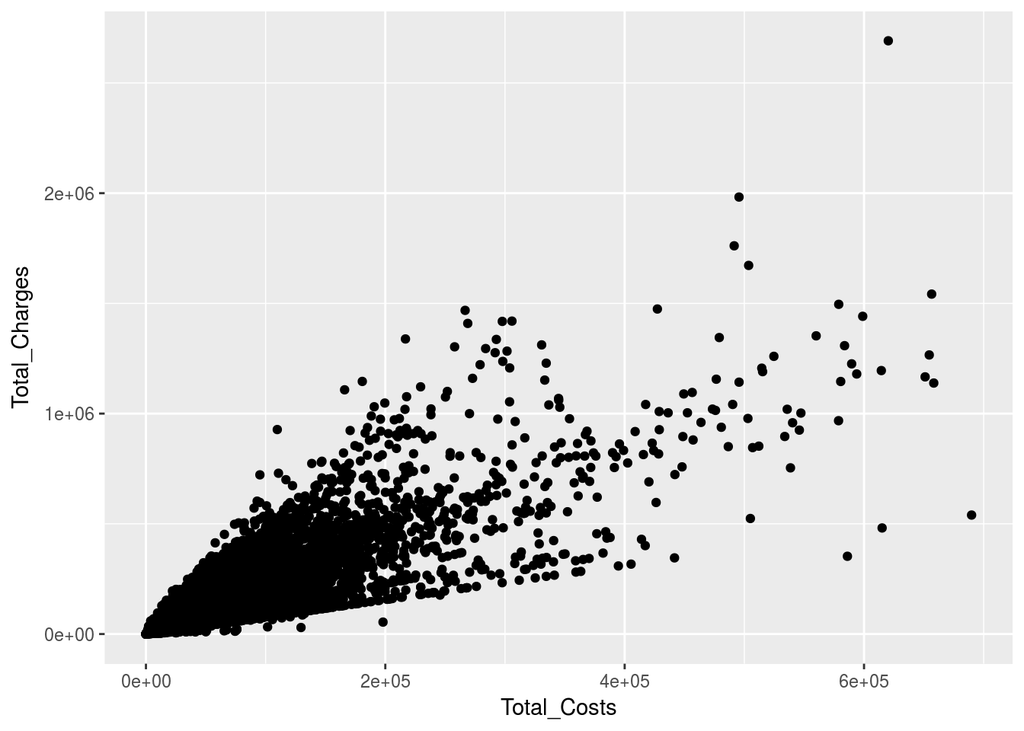

```r
ggplot(ipd_train) + geom_point(aes(x=Total_Costs, y=Total_Charges))
```

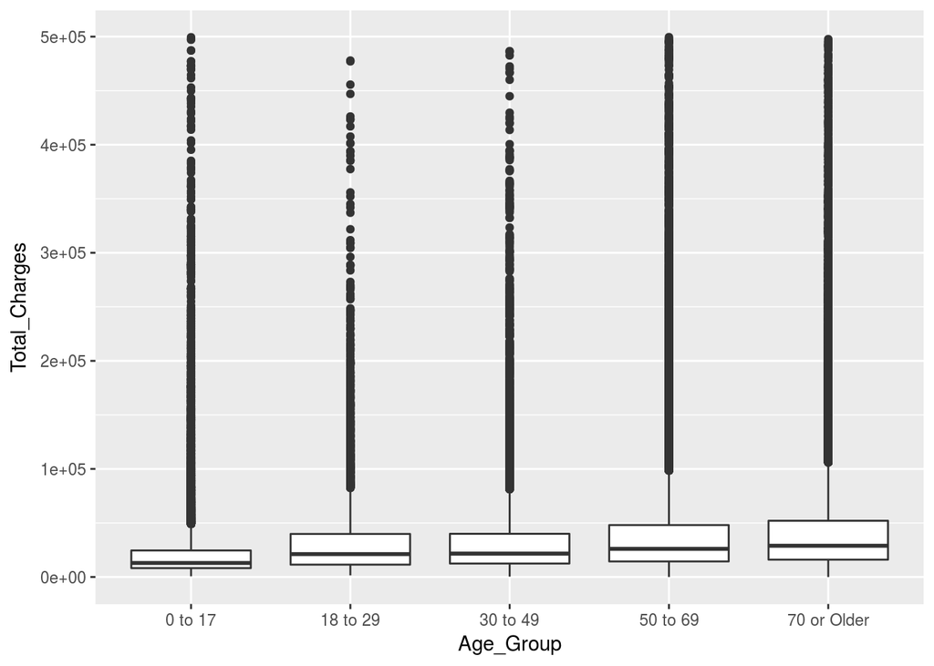

```r
ipd_train %>%
  filter(Total_Charges < 500000) %>%
  ggplot() + geom_boxplot(aes(x=Age_Group, y=Total_Charges))
```

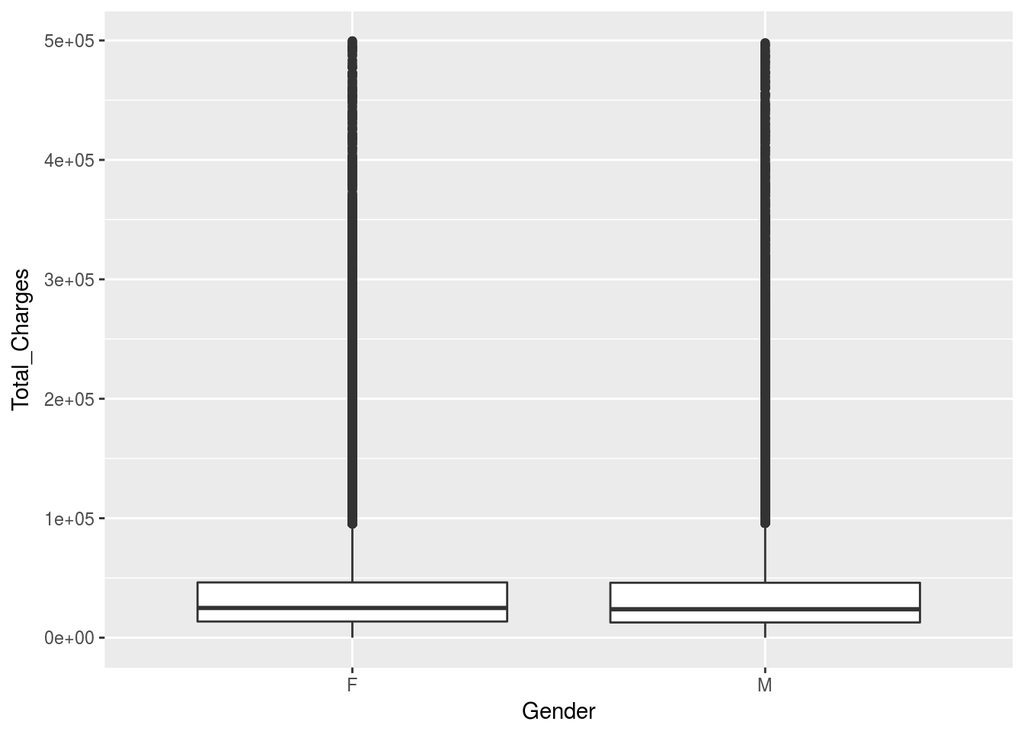

```r
ipd_train %>%
  filter(Total_Charges < 500000) %>%
  ggplot() + geom_boxplot(aes(x=Gender, y=Total_Charges))
```

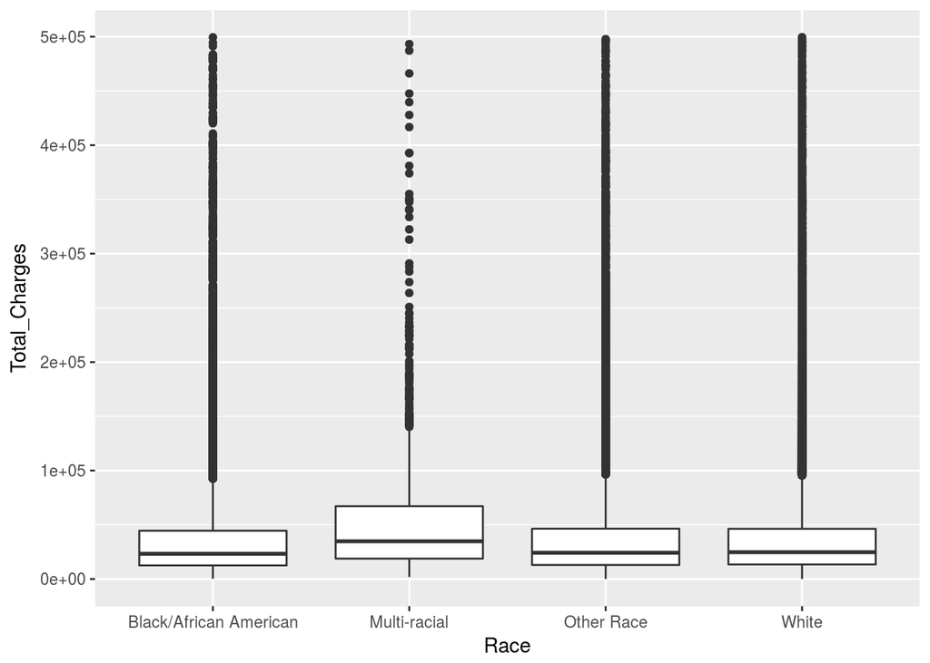

```r
ipd_train %>%
  filter(Total_Charges < 500000) %>%
  ggplot() + geom_boxplot(aes(x=Race, y=Total_Charges))
```

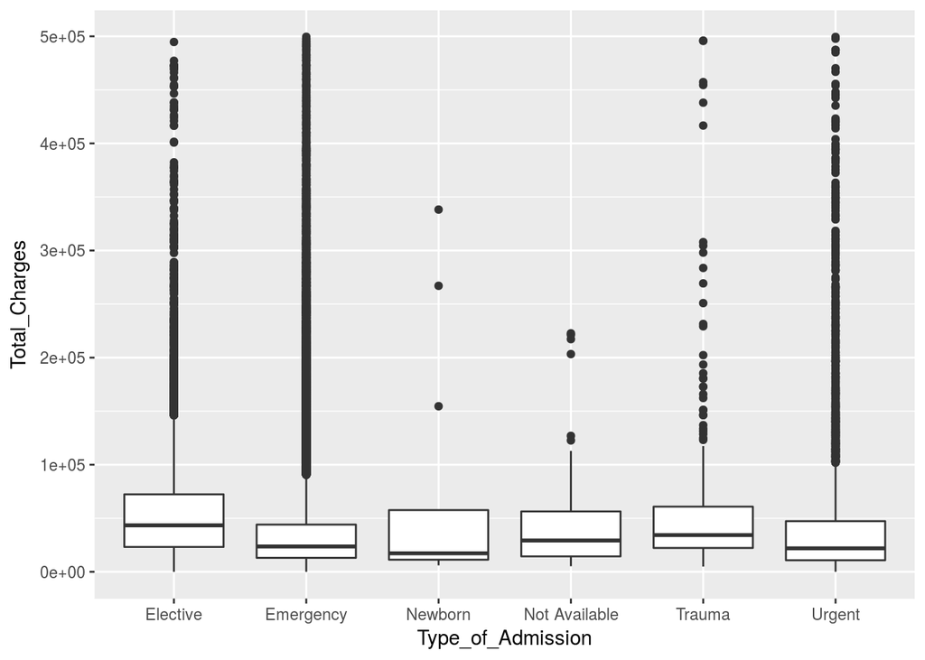

```r
ipd_train %>%
  filter(Total_Charges < 500000) %>%
  ggplot() + geom_boxplot(aes(x=Type_of_Admission, y=Total_Charges))
```

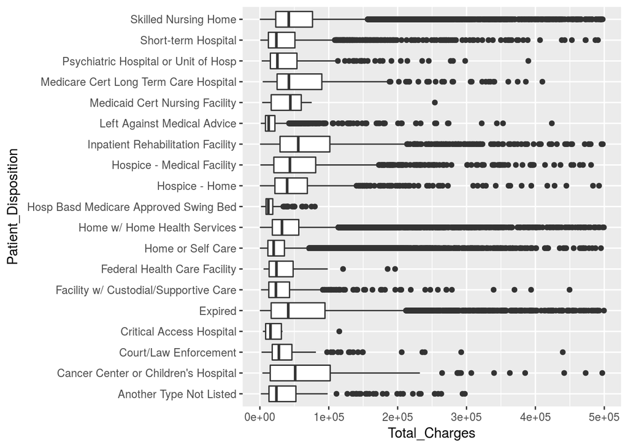

```r
ipd_train %>%
  filter(Total_Charges < 500000) %>%
  ggplot() + geom_boxplot(aes(x=Patient_Disposition, y=Total_Charges)) +
  coord_flip()
```

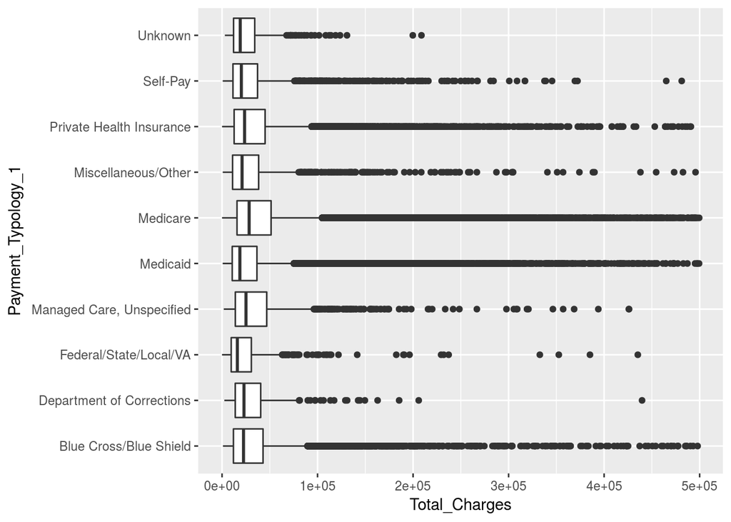

```r
ipd_train %>%
  filter(Total_Charges < 500000) %>%
  ggplot() + geom_boxplot(aes(x=Payment_Typology_1, y=Total_Charges)) +
  coord_flip()
```

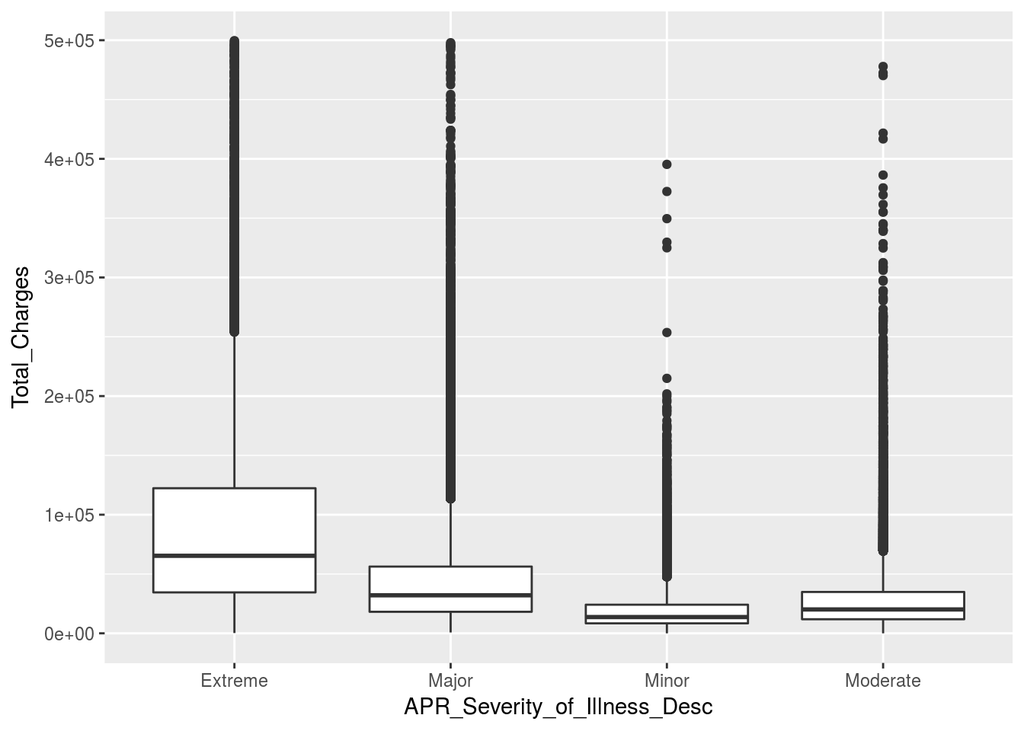

```r
ipd_train %>%
  filter(Total_Charges < 500000) %>%
  ggplot() + geom_boxplot(aes(x=APR_Severity_of_Illness_Desc, y=Total_Charges))
```

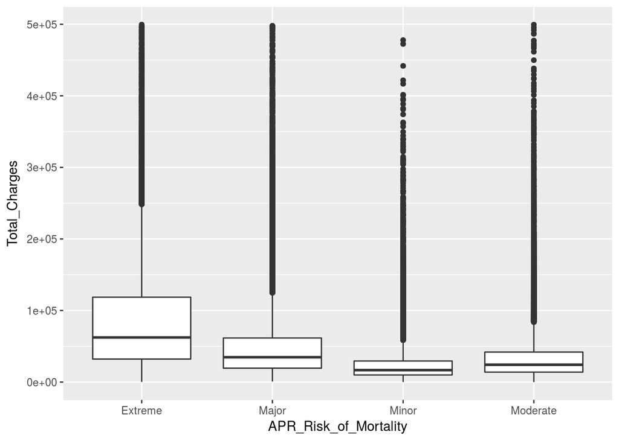

```r
ipd_train %>%
  filter(Total_Charges < 500000) %>%
  ggplot() + geom_boxplot(aes(x=APR_Risk_of_Mortality, y=Total_Charges))
```

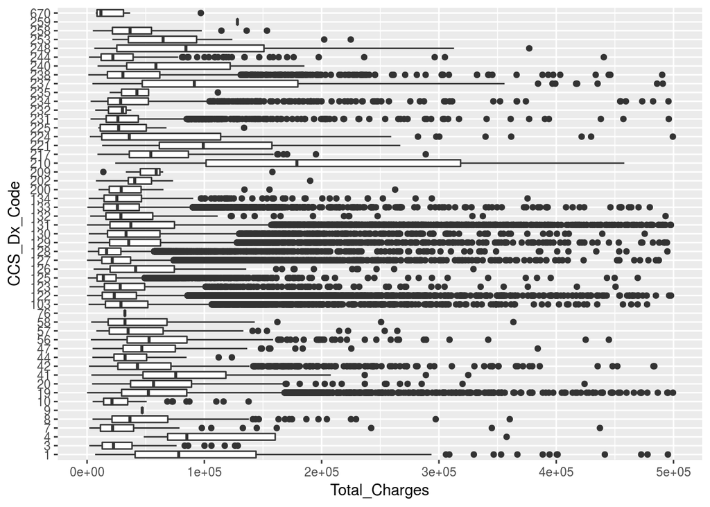

```r
ipd_train %>%
  filter(Total_Charges < 500000) %>%
  ggplot() + geom_boxplot(aes(x=CCS_Dx_Code, y=Total_Charges)) + coord_flip()
```

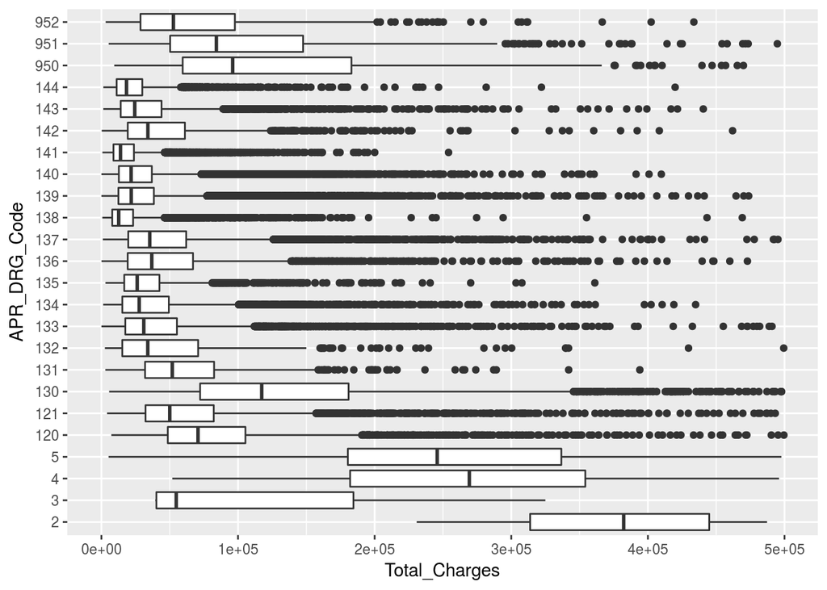

```r
ipd_train %>%
  filter(Total_Charges < 500000) %>%
  ggplot() + geom_boxplot(aes(x=APR_DRG_Code, y=Total_Charges)) + coord_flip()
```

## Step 6 - Building and evaluation of predictive models

Now that you know a little more about the data, it’s time to start building a few predictive models for `Total_Charges`. The error metric that we will use to evaluate the models (both for fit and for predictions) is **median absolute deviation** (MAD). This is nothing more than the median of the absolute value of the residuals for a fitted model.

**QUESTION:** What might be an advantage of using median absolute deviation instead of mean absolute deviation?

> Medians are more robust to outliers than is the mean.

Obviously we want models with lower MAD values. Our ultimate goal is to create a model that predicts well on the test dataset, `ipd_test`.

### Null model

It’s always a good idea to start out with what we call the *null model*. This is the simplest possible model and one that other models better be able to beat. For this regression problem, the null model is simply a regression model that just has a y-intercept. If you remember some of your statistics, you won’t be surprised that the best fit value for the y-intercept in this case is the mean of the response variable, `Total_Charges`.

```r
charges_lm0 <- glm(Total_Charges ~ 1, data = ipd_train)
summary(charges_lm0)
```

```
##
## Call:
## glm(formula = Total_Charges ~ 1, data = ipd_train)
##
## Deviance Residuals:
##     Min       1Q   Median       3Q      Max
##  -41550   -28361   -17067     4885  2649697
##
## Coefficients:
##             Estimate Std. Error t value Pr(>|t|)
## (Intercept)    41551        172   241.5   <2e-16 ***
## ---
## Signif. codes:  0 '***' 0.001 '**' 0.01 '*' 0.05 '.' 0.1 ' ' 1
##
## (Dispersion parameter for gaussian family taken to be 4063529823)
##
##     Null deviance: 5.58e+14  on 137319  degrees of freedom
## Residual deviance: 5.58e+14  on 137319  degrees of freedom
## AIC: 3427949
##
## Number of Fisher Scoring iterations: 2
```

```r
# Compute the MAD value
median(abs(charges_lm0$residuals))
```

```
## [1] 24376.3
```

It’s not hard to create regression models with smaller MAD values than this. :)

Just to give you a benchmark, I built a model on the training set that had a MAD value of 7270.340. Again, this is just the median of the absolute values of the residuals of the fitted model. Later when I used this model on the test data, I got a MAD of … well, I’ll tell you a little later.

### Model building

Using the information you’ve gained from reading about the data and doing some EDA, build several regression models and compute the MAD from each. Summarize your results in terms of which model or models appear to fit well.

```r
charges_lm1 <- glm(Total_Charges ~ Length_of_Stay, data = ipd_train)
summary(charges_lm1)
```

```
##
## Call:
## glm(formula = Total_Charges ~ Length_of_Stay, data = ipd_train)
##
## Deviance Residuals:
##     Min       1Q   Median       3Q      Max
## -665738   -10960    -1784     7017  1908279
##
## Coefficients:
##                Estimate Std. Error t value Pr(>|t|)
## (Intercept)      678.33     136.75    4.96 7.04e-07 ***
## Length_of_Stay  7311.13      15.45  473.36  < 2e-16 ***
## ---
## Signif. codes:  0 '***' 0.001 '**' 0.01 '*' 0.05 '.' 0.1 ' ' 1
##
## (Dispersion parameter for gaussian family taken to be 1544066760)
##
##     Null deviance: 5.5800e+14  on 137319  degrees of freedom
## Residual deviance: 2.1203e+14  on 137318  degrees of freedom
## AIC: 3295075
##
## Number of Fisher Scoring iterations: 2
```

```r
median(abs(charges_lm1$residuals))
```

```
## [1] 9170.777
```

```r
charges_lm2 <- glm(Total_Charges ~ Length_of_Stay + Total_Costs + Age_Group, data = ipd_train)
summary(charges_lm2)
```

```
##
## Call:
## glm(formula = Total_Charges ~ Length_of_Stay + Total_Costs +
##     Age_Group, data = ipd_train)
##
## Deviance Residuals:
##     Min       1Q   Median       3Q      Max
## -804442    -8690    -1159     7063  1400567
##
## Coefficients:
##                  Estimate Std. Error t value Pr(>|t|)
## (Intercept)     1.510e+03  1.346e+02  11.217  < 2e-16 ***
## Length_of_Stay  2.644e+03  1.947e+01 135.773  < 2e-16 ***
## Total_Costs     1.620e+00  5.278e-03 306.994  < 2e-16 ***
## Age_Group.L     1.450e+03  2.228e+02   6.509 7.59e-11 ***
## Age_Group.Q    -1.059e+03  2.334e+02  -4.537 5.72e-06 ***
## Age_Group.C     1.596e+03  3.120e+02   5.115 3.14e-07 ***
## Age_Group^4    -8.684e+02  2.975e+02  -2.919  0.00351 **
## ---
## Signif. codes:  0 '***' 0.001 '**' 0.01 '*' 0.05 '.' 0.1 ' ' 1
##
## (Dispersion parameter for gaussian family taken to be 912101522)
##
##     Null deviance: 5.5800e+14  on 137319  degrees of freedom
## Residual deviance: 1.2524e+14  on 137313  degrees of freedom
## AIC: 3222791
##
## Number of Fisher Scoring iterations: 2
```

```r
median(abs(charges_lm2$residuals))
```

```
## [1] 7963.874
```

```r
charges_lm3 <- glm(Total_Charges ~ Length_of_Stay + Total_Costs + Age_Group * Gender, data = ipd_train)
summary(charges_lm3)
```

```
##
## Call:
## glm(formula = Total_Charges ~ Length_of_Stay + Total_Costs +
##     Age_Group * Gender, data = ipd_train)
##
## Deviance Residuals:
##     Min       1Q   Median       3Q      Max
## -804072    -8677    -1164     7068  1399833
##
## Coefficients:
##                       Estimate Std. Error t value Pr(>|t|)
## (Intercept)          1.341e+03  1.812e+02   7.399 1.38e-13 ***
## Length_of_Stay       2.644e+03  1.947e+01 135.765  < 2e-16 ***
## Total_Costs          1.620e+00  5.279e-03 306.919  < 2e-16 ***
## Age_Group.L          1.356e+03  3.245e+02   4.179 2.93e-05 ***
## Age_Group.Q         -6.435e+02  3.323e+02  -1.937   0.0528 .
## Age_Group.C          9.972e+02  4.470e+02   2.231   0.0257 *
## Age_Group^4         -2.710e+02  4.158e+02  -0.652   0.5145
## GenderM              3.693e+02  2.412e+02   1.531   0.1257
## Age_Group.L:GenderM  1.684e+02  4.435e+02   0.380   0.7041
## Age_Group.Q:GenderM -7.417e+02  4.696e+02  -1.580   0.1142
## Age_Group.C:GenderM  1.135e+03  6.247e+02   1.816   0.0693 .
## Age_Group^4:GenderM -1.171e+03  5.962e+02  -1.965   0.0495 *
## ---
## Signif. codes:  0 '***' 0.001 '**' 0.01 '*' 0.05 '.' 0.1 ' ' 1
##
## (Dispersion parameter for gaussian family taken to be 912069116)
##
##     Null deviance: 5.5800e+14  on 137319  degrees of freedom
## Residual deviance: 1.2523e+14  on 137308  degrees of freedom
## AIC: 3222791
##
## Number of Fisher Scoring iterations: 2
```

```r
median(abs(charges_lm3$residuals))
```

```
## [1] 7970.684
```

```r
charges_lm4 <- glm(Total_Charges ~ Length_of_Stay + Total_Costs +
                  Age_Group + Health_Service_Area, data = ipd_train)
summary(charges_lm4)
```

```
##
## Call:
## glm(formula = Total_Charges ~ Length_of_Stay + Total_Costs +
##     Age_Group + Health_Service_Area, data = ipd_train)
##
## Deviance Residuals:
##     Min       1Q   Median       3Q      Max
## -795990    -8178     -187     6550  1401686
##
## Coefficients:
##                                    Estimate Std. Error t value Pr(>|t|)
## (Intercept)                      -2.043e+03  2.925e+02  -6.987 2.83e-12
## Length_of_Stay                    2.641e+03  1.909e+01 138.372  < 2e-16
## Total_Costs                       1.608e+00  5.240e-03 306.786  < 2e-16
## Age_Group.L                       1.572e+03  2.168e+02   7.251 4.16e-13
## Age_Group.Q                      -1.606e+03  2.249e+02  -7.141 9.34e-13
## Age_Group.C                       1.253e+03  3.005e+02   4.168 3.07e-05
## Age_Group^4                      -1.186e+03  2.866e+02  -4.139 3.49e-05
## Health_Service_AreaCentral NY    -6.278e+03  3.890e+02 -16.138  < 2e-16
## Health_Service_AreaFinger Lakes  -8.087e+03  4.056e+02 -19.941  < 2e-16
## Health_Service_AreaHudson Valley  1.052e+04  3.599e+02  29.232  < 2e-16
## Health_Service_AreaLong Island    1.951e+04  3.431e+02  56.865  < 2e-16
## Health_Service_AreaNew York City  3.490e+03  3.004e+02  11.618  < 2e-16
## Health_Service_AreaSouthern Tier -4.057e+03  7.058e+02  -5.748 9.04e-09
## Health_Service_AreaWestern NY    -6.336e+03  3.922e+02 -16.156  < 2e-16
##
## (Intercept)                      ***
## Length_of_Stay                   ***
## Total_Costs                      ***
## Age_Group.L                      ***
## Age_Group.Q                      ***
## Age_Group.C                      ***
## Age_Group^4                      ***
## Health_Service_AreaCentral NY    ***
## Health_Service_AreaFinger Lakes  ***
## Health_Service_AreaHudson Valley ***
## Health_Service_AreaLong Island   ***
## Health_Service_AreaNew York City ***
## Health_Service_AreaSouthern Tier ***
## Health_Service_AreaWestern NY    ***
## ---
## Signif. codes:  0 '***' 0.001 '**' 0.01 '*' 0.05 '.' 0.1 ' ' 1
##
## (Dispersion parameter for gaussian family taken to be 846045360)
##
##     Null deviance: 5.5800e+14  on 137319  degrees of freedom
## Residual deviance: 1.1617e+14  on 137306  degrees of freedom
## AIC: 3212475
##
## Number of Fisher Scoring iterations: 2
```

```r
median(abs(charges_lm4$residuals))
```

```
## [1] 7270.34
```

```r
charges_lm5 <- glm(Total_Charges ~ Length_of_Stay + Total_Costs +
                  Age_Group + Health_Service_Area + surgery, data = ipd_train)
summary(charges_lm5)
```

```
##
## Call:
## glm(formula = Total_Charges ~ Length_of_Stay + Total_Costs +
##     Age_Group + Health_Service_Area + surgery, data = ipd_train)
##
## Deviance Residuals:
##     Min       1Q   Median       3Q      Max
## -786438    -7993       22     6823  1409195
##
## Coefficients:
##                                    Estimate Std. Error t value Pr(>|t|)
## (Intercept)                      -4.108e+03  2.982e+02 -13.779  < 2e-16
## Length_of_Stay                    2.597e+03  1.906e+01 136.264  < 2e-16
## Total_Costs                       1.597e+00  5.231e-03 305.268  < 2e-16
## Age_Group.L                       1.349e+03  2.160e+02   6.242 4.33e-10
## Age_Group.Q                      -1.307e+03  2.242e+02  -5.829 5.60e-09
## Age_Group.C                       1.142e+03  2.994e+02   3.814 0.000137
## Age_Group^4                      -1.002e+03  2.855e+02  -3.509 0.000451
## Health_Service_AreaCentral NY    -7.437e+03  3.892e+02 -19.111  < 2e-16
## Health_Service_AreaFinger Lakes  -7.690e+03  4.042e+02 -19.026  < 2e-16
## Health_Service_AreaHudson Valley  1.103e+04  3.589e+02  30.730  < 2e-16
## Health_Service_AreaLong Island    1.884e+04  3.425e+02  55.017  < 2e-16
## Health_Service_AreaNew York City  1.748e+03  3.040e+02   5.752 8.85e-09
## Health_Service_AreaSouthern Tier -3.827e+03  7.032e+02  -5.442 5.27e-08
## Health_Service_AreaWestern NY    -6.396e+03  3.907e+02 -16.372  < 2e-16
## surgery                           5.626e+03  1.727e+02  32.567  < 2e-16
##
## (Intercept)                      ***
## Length_of_Stay                   ***
## Total_Costs                      ***
## Age_Group.L                      ***
## Age_Group.Q                      ***
## Age_Group.C                      ***
## Age_Group^4                      ***
## Health_Service_AreaCentral NY    ***
## Health_Service_AreaFinger Lakes  ***
## Health_Service_AreaHudson Valley ***
## Health_Service_AreaLong Island   ***
## Health_Service_AreaNew York City ***
## Health_Service_AreaSouthern Tier ***
## Health_Service_AreaWestern NY    ***
## surgery                          ***
## ---
## Signif. codes:  0 '***' 0.001 '**' 0.01 '*' 0.05 '.' 0.1 ' ' 1
##
## (Dispersion parameter for gaussian family taken to be 839566149)
##
##     Null deviance: 5.5800e+14  on 137319  degrees of freedom
## Residual deviance: 1.1528e+14  on 137305  degrees of freedom
## AIC: 3211420
##
## Number of Fisher Scoring iterations: 2
```

```r
median(abs(charges_lm5$residuals))
```

```
## [1] 7338.235
```

```r
charges_lm6 <- glm(Total_Charges ~ Length_of_Stay + Total_Costs +
                  Age_Group + Health_Service_Area +
                    APR_Severity_of_Illness_Desc, data = ipd_train)
summary(charges_lm6)
```

```
##
## Call:
## glm(formula = Total_Charges ~ Length_of_Stay + Total_Costs +
##     Age_Group + Health_Service_Area + APR_Severity_of_Illness_Desc,
##     data = ipd_train)
##
## Deviance Residuals:
##     Min       1Q   Median       3Q      Max
## -773929    -8156       96     6926  1423537
##
## Coefficients:
##                                        Estimate Std. Error t value
## (Intercept)                           1.117e+04  4.011e+02  27.841
## Length_of_Stay                        2.511e+03  1.924e+01 130.516
## Total_Costs                           1.573e+00  5.253e-03 299.391
## Age_Group.L                           1.834e+02  2.254e+02   0.813
## Age_Group.Q                          -1.680e+03  2.232e+02  -7.527
## Age_Group.C                           1.275e+03  2.981e+02   4.276
## Age_Group^4                          -1.116e+03  2.842e+02  -3.928
## Health_Service_AreaCentral NY        -6.244e+03  3.859e+02 -16.183
## Health_Service_AreaFinger Lakes      -8.095e+03  4.022e+02 -20.126
## Health_Service_AreaHudson Valley      1.060e+04  3.570e+02  29.704
## Health_Service_AreaLong Island        1.976e+04  3.405e+02  58.040
## Health_Service_AreaNew York City      3.830e+03  2.982e+02  12.846
## Health_Service_AreaSouthern Tier     -4.674e+03  7.003e+02  -6.675
## Health_Service_AreaWestern NY        -6.595e+03  3.891e+02 -16.950
## APR_Severity_of_Illness_DescMajor    -1.172e+04  2.888e+02 -40.590
## APR_Severity_of_Illness_DescMinor    -1.497e+04  3.442e+02 -43.481
## APR_Severity_of_Illness_DescModerate -1.346e+04  2.964e+02 -45.404
##                                      Pr(>|t|)
## (Intercept)                           < 2e-16 ***
## Length_of_Stay                        < 2e-16 ***
## Total_Costs                           < 2e-16 ***
## Age_Group.L                             0.416
## Age_Group.Q                          5.21e-14 ***
## Age_Group.C                          1.91e-05 ***
## Age_Group^4                          8.57e-05 ***
## Health_Service_AreaCentral NY         < 2e-16 ***
## Health_Service_AreaFinger Lakes       < 2e-16 ***
## Health_Service_AreaHudson Valley      < 2e-16 ***
## Health_Service_AreaLong Island        < 2e-16 ***
## Health_Service_AreaNew York City      < 2e-16 ***
## Health_Service_AreaSouthern Tier     2.49e-11 ***
## Health_Service_AreaWestern NY         < 2e-16 ***
## APR_Severity_of_Illness_DescMajor     < 2e-16 ***
## APR_Severity_of_Illness_DescMinor     < 2e-16 ***
## APR_Severity_of_Illness_DescModerate  < 2e-16 ***
## ---
## Signif. codes:  0 '***' 0.001 '**' 0.01 '*' 0.05 '.' 0.1 ' ' 1
##
## (Dispersion parameter for gaussian family taken to be 832167185)
##
##     Null deviance: 5.5800e+14  on 137319  degrees of freedom
## Residual deviance: 1.1426e+14  on 137303  degrees of freedom
## AIC: 3210206
##
## Number of Fisher Scoring iterations: 2
```

```r
median(abs(charges_lm6$residuals))
```

```
## [1] 7477.527
```

```r
charges_lm7 <- glm(Total_Charges ~ Length_of_Stay + Total_Costs +
                  Age_Group + Health_Service_Area +
                    APR_Severity_of_Illness_Desc +
                    APR_Risk_of_Mortality, data = ipd_train)
summary(charges_lm7)
```

```
##
## Call:
## glm(formula = Total_Charges ~ Length_of_Stay + Total_Costs +
##     Age_Group + Health_Service_Area + APR_Severity_of_Illness_Desc +
##     APR_Risk_of_Mortality, data = ipd_train)
##
## Deviance Residuals:
##     Min       1Q   Median       3Q      Max
## -774365    -8148       89     6946  1422975
##
## Coefficients:
##                                        Estimate Std. Error t value
## (Intercept)                           1.373e+04  4.519e+02  30.369
## Length_of_Stay                        2.505e+03  1.924e+01 130.201
## Total_Costs                           1.570e+00  5.255e-03 298.864
## Age_Group.L                          -2.396e+02  2.432e+02  -0.985
## Age_Group.Q                          -1.857e+03  2.250e+02  -8.252
## Age_Group.C                           1.199e+03  2.984e+02   4.017
## Age_Group^4                          -1.141e+03  2.841e+02  -4.018
## Health_Service_AreaCentral NY        -6.249e+03  3.857e+02 -16.204
## Health_Service_AreaFinger Lakes      -8.142e+03  4.021e+02 -20.251
## Health_Service_AreaHudson Valley      1.055e+04  3.568e+02  29.574
## Health_Service_AreaLong Island        1.973e+04  3.403e+02  57.986
## Health_Service_AreaNew York City      3.865e+03  2.981e+02  12.967
## Health_Service_AreaSouthern Tier     -4.794e+03  7.001e+02  -6.847
## Health_Service_AreaWestern NY        -6.638e+03  3.889e+02 -17.067
## APR_Severity_of_Illness_DescMajor    -9.625e+03  3.427e+02 -28.088
## APR_Severity_of_Illness_DescMinor    -1.236e+04  4.625e+02 -26.717
## APR_Severity_of_Illness_DescModerate -1.098e+04  4.093e+02 -26.818
## APR_Risk_of_MortalityMajor           -4.605e+03  3.826e+02 -12.037
## APR_Risk_of_MortalityMinor           -5.218e+03  4.938e+02 -10.567
## APR_Risk_of_MortalityModerate        -4.512e+03  4.358e+02 -10.354
##                                      Pr(>|t|)
## (Intercept)                           < 2e-16 ***
## Length_of_Stay                        < 2e-16 ***
## Total_Costs                           < 2e-16 ***
## Age_Group.L                             0.325
## Age_Group.Q                           < 2e-16 ***
## Age_Group.C                          5.89e-05 ***
## Age_Group^4                          5.87e-05 ***
```

[output cut: 8 more lines]

```
## APR_Severity_of_Illness_DescMinor     < 2e-16 ***
## APR_Severity_of_Illness_DescModerate  < 2e-16 ***
## APR_Risk_of_MortalityMajor            < 2e-16 ***
## APR_Risk_of_MortalityMinor            < 2e-16 ***
## APR_Risk_of_MortalityModerate         < 2e-16 ***
## ---
## Signif. codes:  0 '***' 0.001 '**' 0.01 '*' 0.05 '.' 0.1 ' ' 1
##
## (Dispersion parameter for gaussian family taken to be 831269836)
##
##     Null deviance: 5.5800e+14  on 137319  degrees of freedom
## Residual deviance: 1.1413e+14  on 137300  degrees of freedom
## AIC: 3210061
##
## Number of Fisher Scoring iterations: 2
```

```r
median(abs(charges_lm7$residuals))
```

```
## [1] 7487.672
```

```r
charges_lm8 <- glm(Total_Charges ~ Length_of_Stay + Total_Costs +
                  Age_Group + Health_Service_Area +
                    APR_Severity_of_Illness_Desc +
                    APR_Risk_of_Mortality + Payment_Typology_1, data = ipd_train)
summary(charges_lm8)
```

```
##
## Call:
## glm(formula = Total_Charges ~ Length_of_Stay + Total_Costs +
##     Age_Group + Health_Service_Area + APR_Severity_of_Illness_Desc +
##     APR_Risk_of_Mortality + Payment_Typology_1, data = ipd_train)
##
## Deviance Residuals:
##     Min       1Q   Median       3Q      Max
## -783704    -8272     -252     6891  1413265
##
## Coefficients:
##                                               Estimate Std. Error t value
## (Intercept)                                  1.692e+04  5.241e+02  32.290
## Length_of_Stay                               2.462e+03  1.914e+01 128.649
## Total_Costs                                  1.587e+00  5.238e-03 303.054
## Age_Group.L                                 -1.678e+03  2.807e+02  -5.979
## Age_Group.Q                                 -2.502e+03  2.306e+02 -10.851
## Age_Group.C                                  1.562e+03  2.963e+02   5.271
## Age_Group^4                                 -1.003e+03  2.817e+02  -3.562
## Health_Service_AreaCentral NY               -6.159e+03  3.832e+02 -16.072
## Health_Service_AreaFinger Lakes             -7.960e+03  3.992e+02 -19.940
## Health_Service_AreaHudson Valley             1.042e+04  3.541e+02  29.416
## Health_Service_AreaLong Island               1.946e+04  3.380e+02  57.565
## Health_Service_AreaNew York City             4.764e+03  2.976e+02  16.008
## Health_Service_AreaSouthern Tier            -3.382e+03  6.952e+02  -4.865
## Health_Service_AreaWestern NY               -6.543e+03  3.859e+02 -16.955
## APR_Severity_of_Illness_DescMajor           -9.563e+03  3.398e+02 -28.143
## APR_Severity_of_Illness_DescMinor           -1.234e+04  4.588e+02 -26.890
## APR_Severity_of_Illness_DescModerate        -1.096e+04  4.059e+02 -26.999
## APR_Risk_of_MortalityMajor                  -4.547e+03  3.793e+02 -11.988
## APR_Risk_of_MortalityMinor                  -4.946e+03  4.903e+02 -10.087
## APR_Risk_of_MortalityModerate               -4.406e+03  4.322e+02 -10.194
## Payment_Typology_1Department of Corrections -8.255e+03  2.279e+03  -3.622
## Payment_Typology_1Federal/State/Local/VA    -2.483e+03  1.222e+03  -2.032
## Payment_Typology_1Managed Care, Unspecified -1.089e+03  8.481e+02  -1.284
## Payment_Typology_1Medicaid                  -5.898e+03  3.244e+02 -18.182
## Payment_Typology_1Medicare                  -2.143e+03  3.330e+02  -6.437
## Payment_Typology_1Miscellaneous/Other       -1.087e+03  8.644e+02  -1.257
## Payment_Typology_1Private Health Insurance   1.258e+01  3.806e+02   0.033
## Payment_Typology_1Self-Pay                  -2.511e+04  5.864e+02 -42.825
```

[output cut: 26 more lines]

```
## Payment_Typology_1Medicare                  1.23e-10 ***
## Payment_Typology_1Miscellaneous/Other       0.208632
## Payment_Typology_1Private Health Insurance  0.973633
## Payment_Typology_1Self-Pay                   < 2e-16 ***
## Payment_Typology_1Unknown                   0.000340 ***
## ---
## Signif. codes:  0 '***' 0.001 '**' 0.01 '*' 0.05 '.' 0.1 ' ' 1
##
## (Dispersion parameter for gaussian family taken to be 817060730)
##
##     Null deviance: 5.5800e+14  on 137319  degrees of freedom
## Residual deviance: 1.1218e+14  on 137291  degrees of freedom
## AIC: 3207703
##
## Number of Fisher Scoring iterations: 2
```

```r
median(abs(charges_lm8$residuals))
```

```
## [1] 7518.911
```

```r
charges_lm9 <- glm(Total_Charges ~ Length_of_Stay + Total_Costs +
                  Age_Group + Health_Service_Area +
                    APR_Severity_of_Illness_Desc +
                    APR_Risk_of_Mortality + Payment_Typology_1 +
                    Type_of_Admission + Patient_Disposition, data = ipd_train)
summary(charges_lm9)
```

```
##
## Call:
## glm(formula = Total_Charges ~ Length_of_Stay + Total_Costs +
##     Age_Group + Health_Service_Area + APR_Severity_of_Illness_Desc +
##     APR_Risk_of_Mortality + Payment_Typology_1 + Type_of_Admission +
##     Patient_Disposition, data = ipd_train)
##
## Deviance Residuals:
##     Min       1Q   Median       3Q      Max
## -772979    -8210     -182     7059  1419577
##
## Coefficients:
##                                                            Estimate
## (Intercept)                                               1.935e+04
## Length_of_Stay                                            2.461e+03
## Total_Costs                                               1.574e+00
## Age_Group.L                                              -1.811e+03
## Age_Group.Q                                              -2.669e+03
## Age_Group.C                                               1.548e+03
## Age_Group^4                                              -9.072e+02
## Health_Service_AreaCentral NY                            -5.862e+03
## Health_Service_AreaFinger Lakes                          -7.914e+03
## Health_Service_AreaHudson Valley                          1.064e+04
## Health_Service_AreaLong Island                            1.983e+04
## Health_Service_AreaNew York City                          5.021e+03
## Health_Service_AreaSouthern Tier                         -3.318e+03
## Health_Service_AreaWestern NY                            -6.653e+03
## APR_Severity_of_Illness_DescMajor                        -9.886e+03
## APR_Severity_of_Illness_DescMinor                        -1.287e+04
## APR_Severity_of_Illness_DescModerate                     -1.140e+04
## APR_Risk_of_MortalityMajor                               -5.258e+03
## APR_Risk_of_MortalityMinor                               -5.899e+03
## APR_Risk_of_MortalityModerate                            -5.353e+03
## Payment_Typology_1Department of Corrections              -1.577e+04
## Payment_Typology_1Federal/State/Local/VA                 -1.845e+03
## Payment_Typology_1Managed Care, Unspecified              -1.860e+03
## Payment_Typology_1Medicaid                               -5.435e+03
## Payment_Typology_1Medicare                               -1.940e+03
## Payment_Typology_1Miscellaneous/Other                    -2.109e+03
## Payment_Typology_1Private Health Insurance                2.085e+01
```

[output cut: 179 more lines]

```
## Patient_DispositionMedicaid Cert Nursing Facility
## Patient_DispositionMedicare Cert Long Term Care Hospital
## Patient_DispositionPsychiatric Hospital or Unit of Hosp
## Patient_DispositionShort-term Hospital
## Patient_DispositionSkilled Nursing Home                  *
## ---
## Signif. codes:  0 '***' 0.001 '**' 0.01 '*' 0.05 '.' 0.1 ' ' 1
##
## (Dispersion parameter for gaussian family taken to be 810250310)
##
##     Null deviance: 5.5800e+14  on 137319  degrees of freedom
## Residual deviance: 1.1122e+14  on 137268  degrees of freedom
## AIC: 3206576
##
## Number of Fisher Scoring iterations: 2
```

```r
median(abs(charges_lm9$residuals))
```

```
## [1] 7582.109
```

```r
charges_lm10 <- glm(Total_Charges ~ Length_of_Stay + Total_Costs +
                  Age_Group + Health_Service_Area + surgery, data = ipd_train)
summary(charges_lm10)
```

```
##
## Call:
## glm(formula = Total_Charges ~ Length_of_Stay + Total_Costs +
##     Age_Group + Health_Service_Area + surgery, data = ipd_train)
##
## Deviance Residuals:
##     Min       1Q   Median       3Q      Max
## -786438    -7993       22     6823  1409195
##
## Coefficients:
##                                    Estimate Std. Error t value Pr(>|t|)
## (Intercept)                      -4.108e+03  2.982e+02 -13.779  < 2e-16
## Length_of_Stay                    2.597e+03  1.906e+01 136.264  < 2e-16
## Total_Costs                       1.597e+00  5.231e-03 305.268  < 2e-16
## Age_Group.L                       1.349e+03  2.160e+02   6.242 4.33e-10
## Age_Group.Q                      -1.307e+03  2.242e+02  -5.829 5.60e-09
## Age_Group.C                       1.142e+03  2.994e+02   3.814 0.000137
## Age_Group^4                      -1.002e+03  2.855e+02  -3.509 0.000451
## Health_Service_AreaCentral NY    -7.437e+03  3.892e+02 -19.111  < 2e-16
## Health_Service_AreaFinger Lakes  -7.690e+03  4.042e+02 -19.026  < 2e-16
## Health_Service_AreaHudson Valley  1.103e+04  3.589e+02  30.730  < 2e-16
## Health_Service_AreaLong Island    1.884e+04  3.425e+02  55.017  < 2e-16
## Health_Service_AreaNew York City  1.748e+03  3.040e+02   5.752 8.85e-09
## Health_Service_AreaSouthern Tier -3.827e+03  7.032e+02  -5.442 5.27e-08
## Health_Service_AreaWestern NY    -6.396e+03  3.907e+02 -16.372  < 2e-16
## surgery                           5.626e+03  1.727e+02  32.567  < 2e-16
##
## (Intercept)                      ***
## Length_of_Stay                   ***
## Total_Costs                      ***
## Age_Group.L                      ***
## Age_Group.Q                      ***
## Age_Group.C                      ***
## Age_Group^4                      ***
## Health_Service_AreaCentral NY    ***
## Health_Service_AreaFinger Lakes  ***
## Health_Service_AreaHudson Valley ***
## Health_Service_AreaLong Island   ***
## Health_Service_AreaNew York City ***
## Health_Service_AreaSouthern Tier ***
## Health_Service_AreaWestern NY    ***
## surgery                          ***
## ---
## Signif. codes:  0 '***' 0.001 '**' 0.01 '*' 0.05 '.' 0.1 ' ' 1
##
## (Dispersion parameter for gaussian family taken to be 839566149)
##
##     Null deviance: 5.5800e+14  on 137319  degrees of freedom
## Residual deviance: 1.1528e+14  on 137305  degrees of freedom
## AIC: 3211420
##
## Number of Fisher Scoring iterations: 2
```

```r
median(abs(charges_lm10$residuals))
```

```
## [1] 7338.235
```

```r
charges_lm11 <- glm(Total_Charges ~ Total_Costs +
                  Age_Group + Health_Service_Area, data = ipd_train)
summary(charges_lm11)
```

```
##
## Call:
## glm(formula = Total_Charges ~ Total_Costs + Age_Group + Health_Service_Area,
##     data = ipd_train)
##
## Deviance Residuals:
##     Min       1Q   Median       3Q      Max
## -972853    -8481     -875     5498  1320990
##
## Coefficients:
##                                    Estimate Std. Error t value Pr(>|t|)
## (Intercept)                       5.075e+03  3.073e+02  16.515  < 2e-16
## Total_Costs                       2.185e+00  3.388e-03 644.800  < 2e-16
## Age_Group.L                       5.125e+03  2.298e+02  22.306  < 2e-16
## Age_Group.Q                      -1.057e+03  2.400e+02  -4.404 1.06e-05
## Age_Group.C                       1.450e+03  3.208e+02   4.518 6.24e-06
## Age_Group^4                      -1.330e+03  3.059e+02  -4.349 1.37e-05
## Health_Service_AreaCentral NY    -7.074e+03  4.152e+02 -17.036  < 2e-16
## Health_Service_AreaFinger Lakes  -8.233e+03  4.329e+02 -19.018  < 2e-16
## Health_Service_AreaHudson Valley  9.884e+03  3.841e+02  25.729  < 2e-16
## Health_Service_AreaLong Island    1.892e+04  3.663e+02  51.660  < 2e-16
## Health_Service_AreaNew York City -1.240e+03  3.186e+02  -3.892 9.94e-05
## Health_Service_AreaSouthern Tier -3.933e+03  7.535e+02  -5.220 1.79e-07
## Health_Service_AreaWestern NY    -6.985e+03  4.186e+02 -16.686  < 2e-16
##
## (Intercept)                      ***
## Total_Costs                      ***
## Age_Group.L                      ***
## Age_Group.Q                      ***
## Age_Group.C                      ***
## Age_Group^4                      ***
## Health_Service_AreaCentral NY    ***
## Health_Service_AreaFinger Lakes  ***
## Health_Service_AreaHudson Valley ***
## Health_Service_AreaLong Island   ***
## Health_Service_AreaNew York City ***
## Health_Service_AreaSouthern Tier ***
## Health_Service_AreaWestern NY    ***
## ---
## Signif. codes:  0 '***' 0.001 '**' 0.01 '*' 0.05 '.' 0.1 ' ' 1
##
## (Dispersion parameter for gaussian family taken to be 964015878)
##
##     Null deviance: 5.5800e+14  on 137319  degrees of freedom
## Residual deviance: 1.3237e+14  on 137307  degrees of freedom
## AIC: 3230399
##
## Number of Fisher Scoring iterations: 2
```

```r
median(abs(charges_lm11$residuals))
```

```
## [1] 6967.487
```

```r
fit_mad0 <- median(abs(charges_lm0$residuals))
fit_mad1 <- median(abs(charges_lm1$residuals))
fit_mad2 <- median(abs(charges_lm2$residuals))
fit_mad3 <- median(abs(charges_lm3$residuals))
fit_mad4 <- median(abs(charges_lm4$residuals))
fit_mad5 <- median(abs(charges_lm5$residuals))
fit_mad6 <- median(abs(charges_lm6$residuals))
fit_mad7 <- median(abs(charges_lm7$residuals))
fit_mad8 <- median(abs(charges_lm8$residuals))
fit_mad9 <- median(abs(charges_lm9$residuals))
fit_mad10 <- median(abs(charges_lm10$residuals))
fit_mad11 <- median(abs(charges_lm11$residuals))

fit_mad <- data.frame(fit_mad0, fit_mad1, fit_mad2, fit_mad3, fit_mad4, fit_mad5,
                      fit_mad6, fit_mad7, fit_mad8, fit_mad9, fit_mad10,
                      fit_mad11)

fit_mad
```

```
##   fit_mad0 fit_mad1 fit_mad2 fit_mad3 fit_mad4 fit_mad5 fit_mad6 fit_mad7
## 1  24376.3 9170.777 7963.874 7970.684  7270.34 7338.235 7477.527 7487.672
##   fit_mad8 fit_mad9 fit_mad10 fit_mad11
## 1 7518.911 7582.109  7338.235  6967.487
```

Identify your top 3 models in terms of lowest MAD values to use in the next part in which you’ll use them to make predictions on the test dataset.

> I’m going to reshape the fit_mad data frame to sort by mad.

```r
fit_mad_long <- tidyr::gather(fit_mad, key = "metric", value = "mad")
fit_mad_long$model <- seq(0,11)
fit_mad_long %>% arrange(mad)
```

```
##       metric       mad model
## 1  fit_mad11  6967.487    11
## 2   fit_mad4  7270.340     4
## 3   fit_mad5  7338.235     5
## 4  fit_mad10  7338.235    10
## 5   fit_mad6  7477.527     6
## 6   fit_mad7  7487.672     7
## 7   fit_mad8  7518.911     8
## 8   fit_mad9  7582.109     9
## 9   fit_mad2  7963.874     2
## 10  fit_mad3  7970.684     3
## 11  fit_mad1  9170.777     1
## 12  fit_mad0 24376.304     0
```

So, my top 3 from MAD based on a single train fit is:

- charges_lm11
- charges_lm4
- charges_lm10 and charges_lm5

**HACKER EXTRA:** Use k-crossfold validation to select your top 3 models.

To use k-crossfold validation, we need to pass in a cost function representing the MAD metric.

```r
mad <- function(observed, predicted) {
  median(abs(observed - predicted))
}
```

```r
library(boot)
```

```r
kcv_lm1 <- cv.glm(ipd_train, charges_lm1, cost = mad, K = 5)
kcv_lm2 <- cv.glm(ipd_train, charges_lm2, cost = mad, K = 5)
kcv_lm3 <- cv.glm(ipd_train, charges_lm3, cost = mad, K = 5)
kcv_lm4 <- cv.glm(ipd_train, charges_lm4, cost = mad, K = 5)
kcv_lm5 <- cv.glm(ipd_train, charges_lm5, cost = mad, K = 5)
kcv_lm6 <- cv.glm(ipd_train, charges_lm6, cost = mad, K = 5)
kcv_lm7 <- cv.glm(ipd_train, charges_lm7, cost = mad, K = 5)
kcv_lm8 <- cv.glm(ipd_train, charges_lm8, cost = mad, K = 5)
kcv_lm9 <- cv.glm(ipd_train, charges_lm9, cost = mad, K = 5)
kcv_lm10 <- cv.glm(ipd_train, charges_lm10, cost = mad, K = 5)
kcv_lm11 <- cv.glm(ipd_train, charges_lm11, cost = mad, K = 5)
```

Gather up the results into a dataframe.

```r
kcv_mads <- as.data.frame(rbind(kcv_lm1$delta,
                                kcv_lm2$delta,
                                kcv_lm3$delta,
                                kcv_lm4$delta,
                                kcv_lm5$delta,
                                kcv_lm6$delta,
                                kcv_lm7$delta,
                                kcv_lm8$delta,
                                kcv_lm9$delta,
                                kcv_lm10$delta,
                                kcv_lm11$delta))

names(kcv_mads) <- c("MAD", "Adj MAD")
kcv_mads$model <- seq(1,11)
```

Let’s see who wins.

```r
kcv_mads %>%
  arrange(MAD)
```

```
##         MAD  Adj MAD model
## 1  6974.659 6974.543    11
## 2  7279.720 7270.275     4
## 3  7346.512 7341.901     5
## 4  7347.344 7344.259    10
## 5  7476.735 7476.088     6
## 6  7484.691 7488.174     7
## 7  7529.208 7527.554     8
## 8  7593.163 7587.005     9
## 9  7958.391 7960.356     2
## 10 7969.539 7968.106     3
## 11 9173.719 9170.315     1
```

> Results are very similar to original results from single training fit. However, lm5 beats lm10 in the k-crossfold validation.

### Model diagnostics

```r
charges_fits <- data.frame(yhat1=charges_lm1$fitted.values,
                           yhat2=charges_lm2$fitted.values,
                           yhat3=charges_lm3$fitted.values,
                           yhat4=charges_lm4$fitted.values,
                           yhat5=charges_lm5$fitted.values,
                           yhat6=charges_lm6$fitted.values,
                           yhat7=charges_lm7$fitted.values,
                           yhat8=charges_lm8$fitted.values,
                           yhat9=charges_lm9$fitted.values,
                           yhat10=charges_lm10$fitted.values,
                           yhat11=charges_lm11$fitted.values,
                           yact=ipd_train$Total_Charges)
```

#### Scatterplots of actual vs fitted values

For your top 3 models, create a scatter plot showing actual vs fitted values of `Total_Charges`. Remember, it’s often nice to “gather up” your results into a data frame to facilitate plotting. See the notes on comparing competing regression models. Here’s what one of my scatterplots looks like.

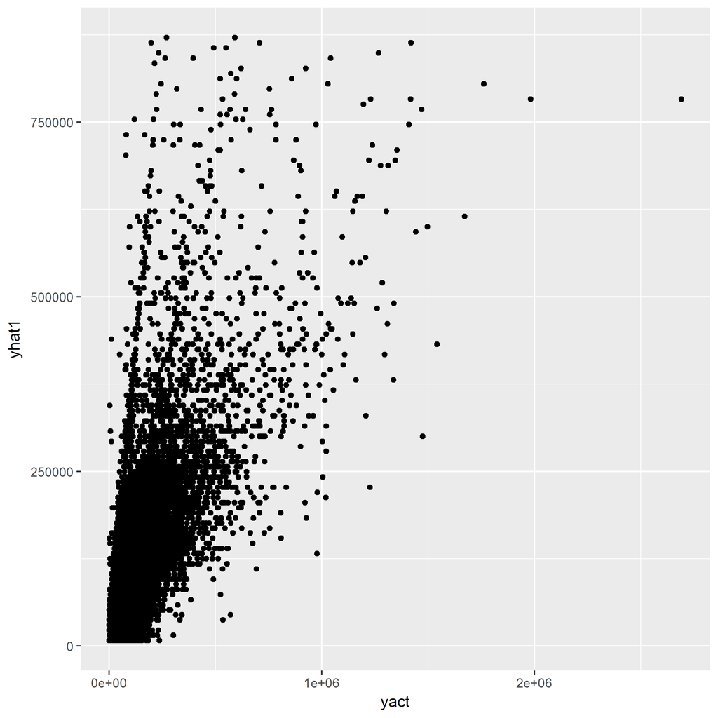

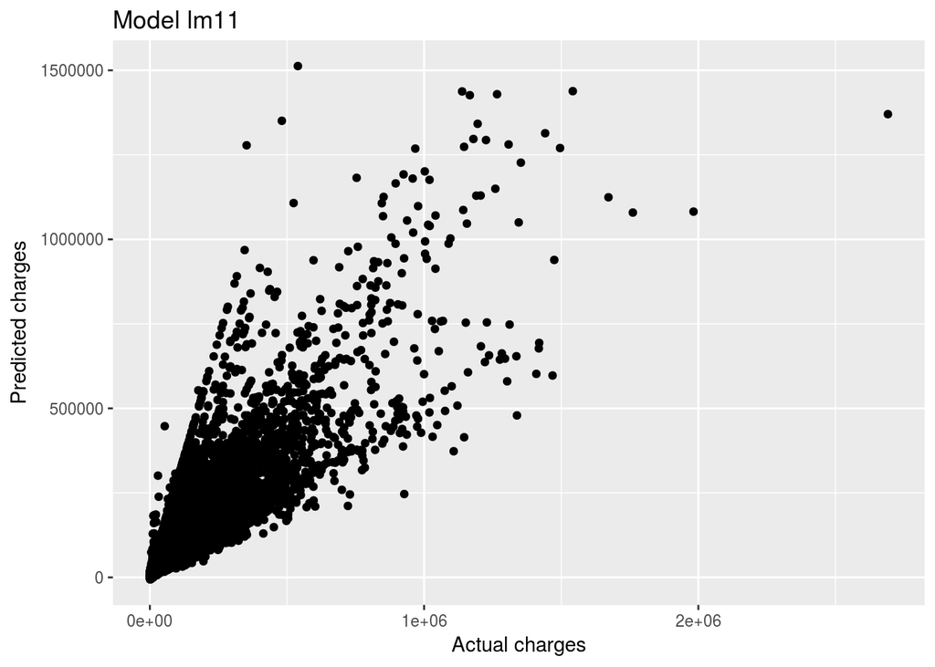

```r
ggplot(charges_fits) +
  geom_point(aes(x=yact, y=yhat11)) +
  labs(x="Actual charges", y="Predicted charges", title="Model lm11")
```

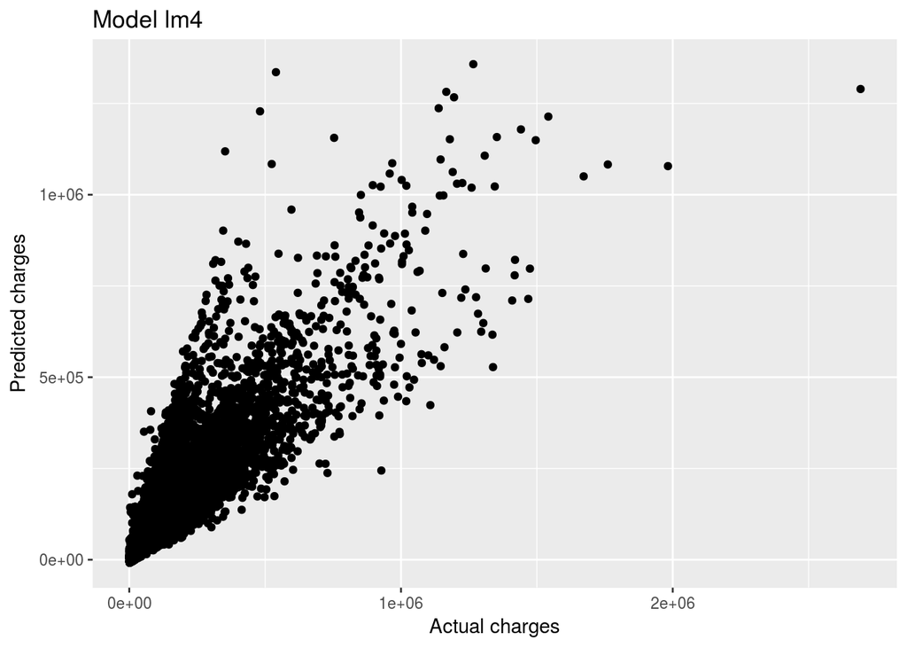

```r
ggplot(charges_fits) +
  geom_point(aes(x=yact, y=yhat4)) +
  labs(x="Actual charges", y="Predicted charges", title="Model lm4")
```

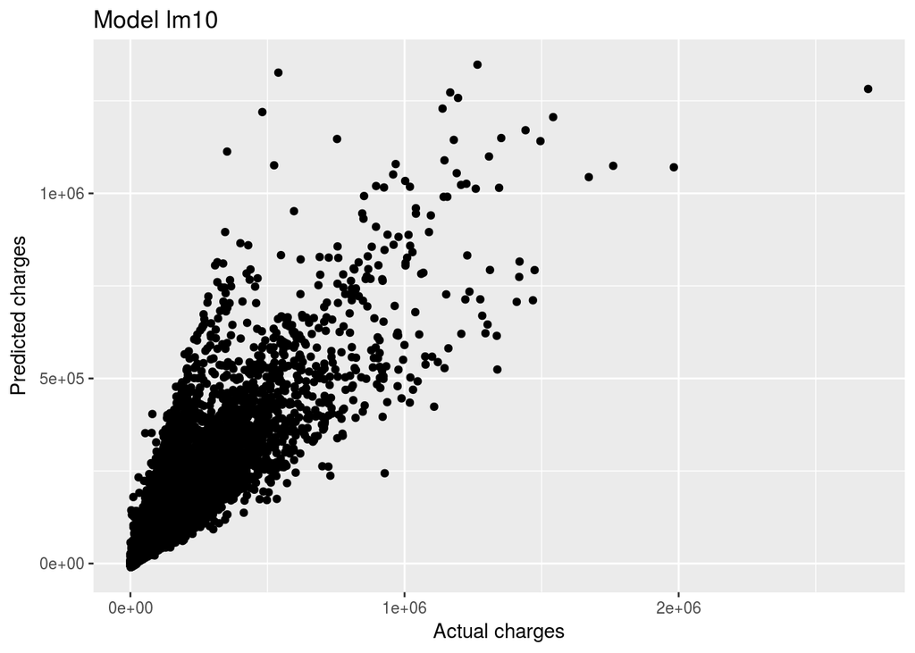

```r
ggplot(charges_fits) +
  geom_point(aes(x=yact, y=yhat10)) +
  labs(x="Actual charges", y="Predicted charges", title="Model lm10")
```

#### Normality of residuals

Create a histogram of the residuals for your top 3 models. You may have to tweak the axes scales to make a nice histogram.

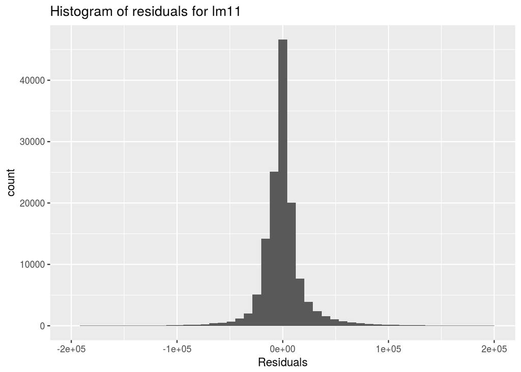

```r
ggplot(data = data.frame(resids = charges_lm11$residuals)) +
  geom_histogram(aes(x = resids), bins = 50) + xlim(-200000, 200000) +
  labs(x="Residuals", title="Histogram of residuals for lm11")
```

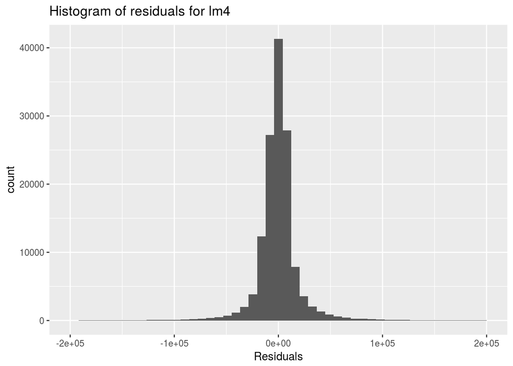

```r
ggplot(data = data.frame(resids = charges_lm4$residuals)) +
  geom_histogram(aes(x = resids), bins = 50) + xlim(-200000, 200000) +
  labs(x="Residuals", title="Histogram of residuals for lm4")
```

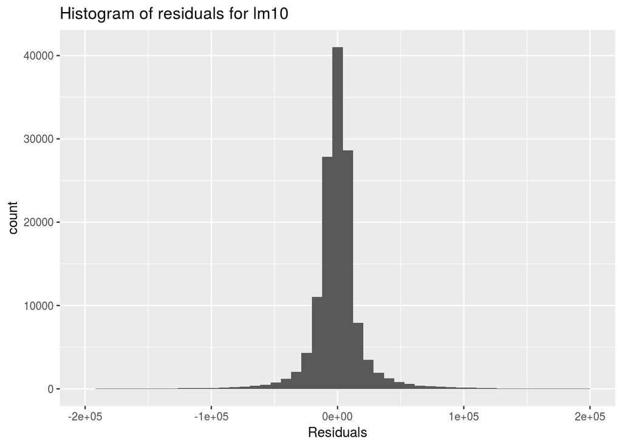

```r
ggplot(data = data.frame(resids = charges_lm10$residuals)) +
  geom_histogram(aes(x = resids), bins = 50) + xlim(-200000, 200000) +
  labs(x="Residuals", title="Histogram of residuals for lm10")
```

All three histograms look somewhat like normal distributions. Let’s compute the skew and kurtosis. The normal distribution has skew and kurtosis values of zero.

```r
e1071::skewness(charges_lm11$residuals)
```

```
## [1] 2.843548
```

```r
e1071::skewness(charges_lm4$residuals)
```

```
## [1] 3.092175
```

```r
e1071::skewness(charges_lm10$residuals)
```

```
## [1] 3.268482
```

```r
e1071::kurtosis(charges_lm11$residuals)
```

```
## [1] 135.476
```

```r
e1071::kurtosis(charges_lm4$residuals)
```

```
## [1] 146.2516
```

```r
e1071::kurtosis(charges_lm10$residuals)
```

```
## [1] 149.4835
```

#### Constant variance

Make an appropriate plot to check for constant variance (homeskedasticity) for your top model. Don’t remember what kind of plot to make? See my notes on residual analysis or any intro stats book.

> Plot residuals vs fitted values to assess constancy of variance.

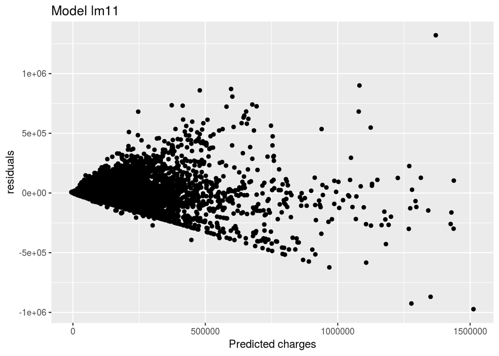

```r
ggplot(data.frame(yhat11 = charges_fits$yhat11, residuals = charges_lm11$residuals)) +
  geom_point(aes(y=residuals, x=yhat11)) +
  labs(y="residuals", x="Predicted charges", title="Model lm11")
```

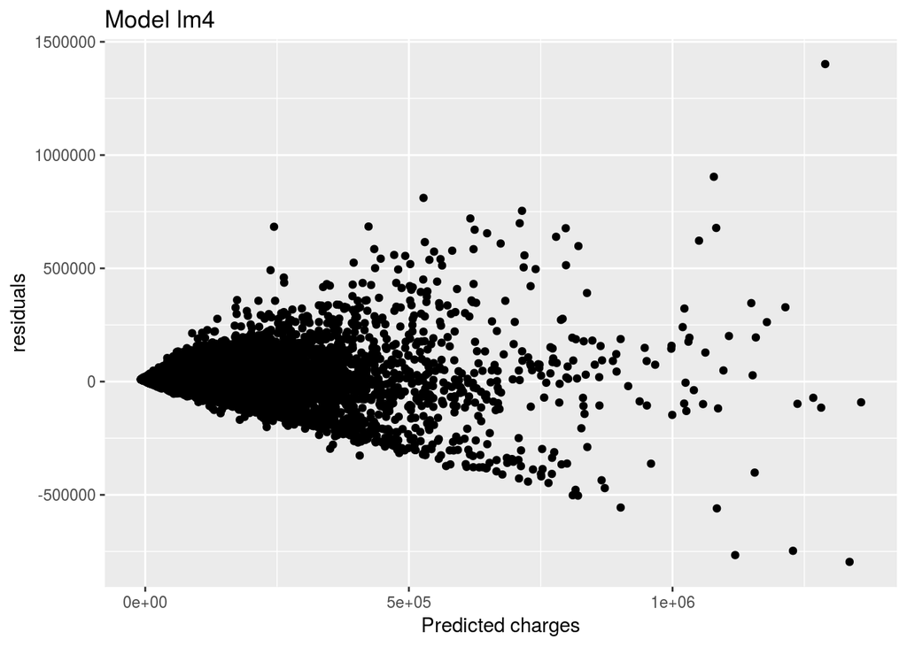

```r
ggplot(data.frame(yhat4 = charges_fits$yhat4, residuals = charges_lm4$residuals)) +
  geom_point(aes(y=residuals, x=yhat4)) +
  labs(y="residuals", x="Predicted charges", title="Model lm4")
```

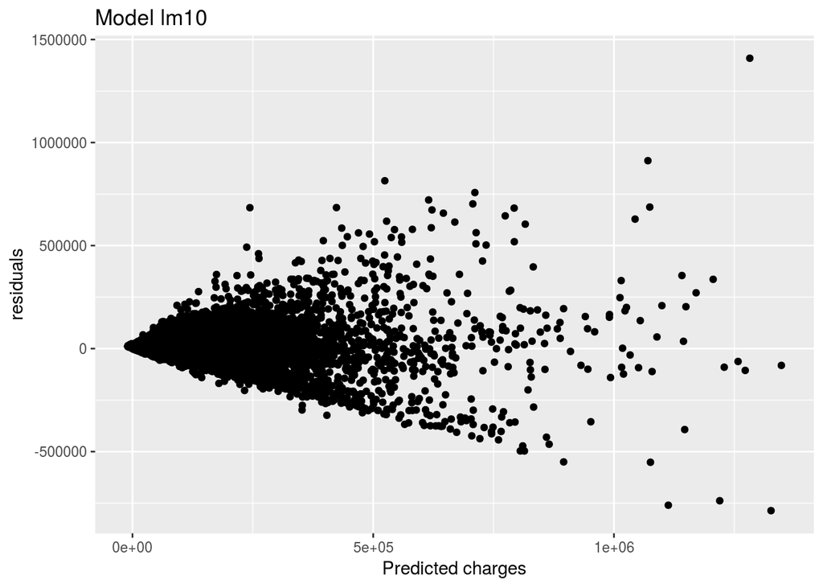

```r
ggplot(data.frame(yhat10 = charges_fits$yhat10, residuals = charges_lm10$residuals)) +
  geom_point(aes(y=residuals, x=yhat10)) +
  labs(y="residuals", x="Predicted charges", title="Model lm10")
```

> Errors appear to “fan out”. Our errors are not constant - we predict better on lower values.

### Make predictions for the test dataset

For each of your top 3 models, make predictions for `ipd_test`. I did predictions for all the models.

```r
pred_lm0 <- predict(charges_lm0, newdata = ipd_test)
pred_lm1 <- predict(charges_lm1, newdata = ipd_test)
pred_lm2 <- predict(charges_lm2, newdata = ipd_test)
pred_lm3 <- predict(charges_lm3, newdata = ipd_test)
pred_lm4 <- predict(charges_lm4, newdata = ipd_test)
pred_lm5 <- predict(charges_lm5, newdata = ipd_test)
pred_lm6 <- predict(charges_lm6, newdata = ipd_test)
pred_lm7 <- predict(charges_lm7, newdata = ipd_test)
pred_lm8 <- predict(charges_lm8, newdata = ipd_test)
pred_lm9 <- predict(charges_lm9, newdata = ipd_test)
pred_lm10 <- predict(charges_lm10, newdata = ipd_test)
pred_lm11 <- predict(charges_lm11, newdata = ipd_test)
```

```r
pred_mad0 <- median(abs(pred_lm0 - ipd_test$Total_Charges))
pred_mad1 <- median(abs(pred_lm1 - ipd_test$Total_Charges))
pred_mad2 <- median(abs(pred_lm2 - ipd_test$Total_Charges))
pred_mad3 <- median(abs(pred_lm3 - ipd_test$Total_Charges))
pred_mad4 <- median(abs(pred_lm4 - ipd_test$Total_Charges))
pred_mad5 <- median(abs(pred_lm5 - ipd_test$Total_Charges))
pred_mad6 <- median(abs(pred_lm6 - ipd_test$Total_Charges))
pred_mad7 <- median(abs(pred_lm7 - ipd_test$Total_Charges))
pred_mad8 <- median(abs(pred_lm8 - ipd_test$Total_Charges))
pred_mad9 <- median(abs(pred_lm9 - ipd_test$Total_Charges))
pred_mad10 <- median(abs(pred_lm10 - ipd_test$Total_Charges))
pred_mad11 <- median(abs(pred_lm11 - ipd_test$Total_Charges))

pred_mad <- data.frame(pred_mad0, pred_mad1, pred_mad2, pred_mad3, pred_mad4,
                      pred_mad5, pred_mad6, pred_mad7, pred_mad8, pred_mad9,
                      pred_mad10, pred_mad11)

pred_mad
```

```
##   pred_mad0 pred_mad1 pred_mad2 pred_mad3 pred_mad4 pred_mad5 pred_mad6
## 1   24359.2  9113.005   7980.03  7972.278  7335.559  7336.741  7511.881
##   pred_mad7 pred_mad8 pred_mad9 pred_mad10 pred_mad11
## 1  7515.779  7554.402  7645.096   7336.741   6947.697
```

```r
pred_mad_long <- tidyr::gather(pred_mad, key = "metric", value = "mad")
pred_mad_long$model <- seq(0,11)
pred_mad_long %>% arrange(mad)
```

```
##        metric       mad model
## 1  pred_mad11  6947.697    11
## 2   pred_mad4  7335.559     4
## 3   pred_mad5  7336.741     5
## 4  pred_mad10  7336.741    10
## 5   pred_mad6  7511.881     6
## 6   pred_mad7  7515.779     7
## 7   pred_mad8  7554.402     8
## 8   pred_mad9  7645.096     9
## 9   pred_mad3  7972.278     3
## 10  pred_mad2  7980.030     2
## 11  pred_mad1  9113.005     1
## 12  pred_mad0 24359.199     0
```

### Evaluate the predictions

Compute the MAD for each of the three models’ predictions on the test data.

HINT: Obviously you can’t use the residuals (or errors) directly but will have to compute them. They are simply the difference between the actual values and your predicted values.

So, for the model I mentioned earlier that had a MAD of 7270.340 for the training data, the MAD on the test data was 7335.559. Notice that MAD for test is higher than MAD for train.

**QUESTION:** Do you think it’s typical that MAD for test would be higher than MAD for train? Why or why not?

**QUESTION:** Which of your top 3 models had the lowest MAD for the test data?

> My top 3 for prediction were same as top 3 on training - 11, 4, 5 (tied with 10)

**QUESTION:** How do the MAD values for the test data compare to the MAD values for the training data?

> See plot below. Pretty similar performance on train and test.

Finally, create some sort of plot which shows the MAD values for both train and test for your top 3 models. One plot.

Create summary dataframe to make plot easy.

```r
mad_summary <- fit_mad_long[,c(3,2)]
names(mad_summary)[2] <- "fit_mad"
mad_summary <- cbind(mad_summary, pred_mad_long$mad)
names(mad_summary)[3] <- "pred_mad"
```

```r
mad_summary_long <- tidyr::gather(mad_summary, key="metric", value="mad", 2:3)
```

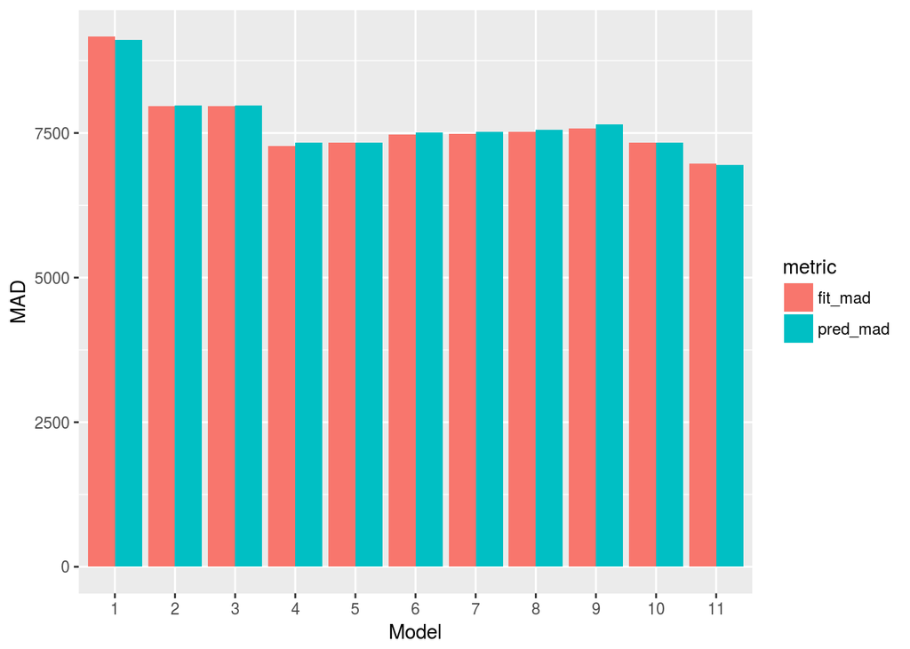

```r
ggplot(mad_summary_long %>% filter(model > 0)) +
  geom_bar(aes(x=as.factor(model), y=mad, fill=metric), stat="identity", position = position_dodge()) +
  labs(x = "Model", y = "MAD")
```

### Your top model

Show your top performing model and discuss whether the model appears to make sense in terms of the variables included. Why did you choose the variables you did?

> I figured that total costs would be a good predictor of charges and thought length of stay would as well. Age also seemed promising from what I know of hospital finances and the boxplot gave more evidence. I also thought regional differences could play a role, which turned out to be true. However, I really thought that some of the other clinical variables related to severity or diagnosis or procedures done would be more predictive. They weren’t. My best model was very simple in that it only included costs, age group, and the service area. Surprising. In order to significantly outpeform simple multiple regression models, it seems that better data transformations are needed. See the exemplars for some clever log transforming that led to much better models. It will also be interesting to see if techniques such as random forests are able to outperform our best regression models.

It will be interesting to compare the best models that everyone finds.

Later we’ll learn more techniques that will likely allow us to beat simple linear models.